# MSDS458_Assignment_01_Experiment 4

Parviz Ali NU Fall 2021, Prof. Srinivasan

## MSDS458 Research Assignment 1 Experiment 4:

90 Hidden Neurons (Best Network) Changing input to 154

```python
import datetime
from packaging import version
from collections import Counter
import numpy as np
import pandas as pd

import matplotlib as mpl  # EA
import matplotlib.pyplot as plt
from mpl_toolkits.mplot3d import Axes3D
import seaborn as sns

from sklearn.metrics import confusion_matrix, classification_report
from sklearn.preprocessing import StandardScaler
from sklearn.decomposition import PCA
from sklearn.manifold import TSNE
from sklearn.ensemble import RandomForestClassifier
from sklearn.metrics import mean_squared_error as MSE
from sklearn.metrics import accuracy_score

import tensorflow as tf
from tensorflow.keras.utils import to_categorical
from tensorflow import keras
from tensorflow.keras import models
from tensorflow.keras.models import Sequential
from tensorflow.keras.layers import Dense, Flatten
from tensorflow.keras.datasets import mnist
#from plot_keras_history import plot_history
```

```python
%matplotlib inline
np.set_printoptions(precision=3, suppress=True)
```

### Functions For Research Assignment

```python
def print_validation_report(test_labels, predictions):
    print("Classification Report")
    print(classification_report(test_labels, predictions))
    print('Accuracy Score: {}'.format(accuracy_score(test_labels, predictions)))
    print('Root Mean Square Error: {}'.format(np.sqrt(MSE(test_labels, predictions))))
```

```python
def plot_confusion_matrix(y_true, y_pred):
    mtx = confusion_matrix(y_true, y_pred)
    fig, ax = plt.subplots(figsize=(8,8))
    sns.heatmap(mtx, annot=True, fmt='d', linewidths=.75,  cbar=False, ax=ax,cmap='Blues',linecolor='white')
    #  square=True,
    plt.ylabel('true label')
    plt.xlabel('predicted label')
```

## 2. Loading MNIST Dataset

- The MNIST dataset of handwritten digits has a training set of 60,000 images, and a test set of 10,000 images. It comes prepackaged as part of `tf.Keras`. Use the `tf.keras.datasets.mnist.load_data` to the get these datasets (and the corresponding labels) as Numpy arrays.

```python
(train_images, train_labels), (test_images, test_labels) = mnist.load_data()
```

- Tuples of Numpy arrays: `(x_train, y_train)`, `(x_test, y_test)`
- `x_train`, `x_test`: uint8 arrays of grayscale image data with shapes (num_samples, 28, 28).
- `y_train`, `y_test`: uint8 arrays of digit labels (integers in range 0-9)

## Preparing the data

Before training, we will preprocess our data by reshaping it into the shape that the network expects, and scaling it so that all values are in the [0, 1] interval.

Our training images are stored in an array of shape (60000, 28, 28) of type uint8 with values in the [0, 255] interval.

We transform it into a float32 array of shape (60000, 28 * 28) with values between 0 and 1.

```python
train_images = train_images.reshape((60000, 28 * 28))
train_images = train_images.astype('float32') / 255

test_images = test_images.reshape((10000, 28 * 28))
test_images = test_images.astype('float32') / 255
```

### Validating our approach

We set apart 5,000 samples of our training data to use as a validation set. Since we will be using sparse_categorical_crossentropy as the loss function we do not need to use to_categorical to convert the class vector of labels to binary matrix representation.

```python
val_images, train_images = train_images[:5000], train_images[5000:]
val_labels, train_labels = train_labels[:5000], train_labels[5000:]
```

## Reducing dimensionality of the data with PCA decomposition.

We use PCA decomposition to reduce the number of dimensions of our training set of 28x28 dimensional MNIST images. By setting n_components=0.95 we get the 154 principal components that contain 95% of the variance (information) in the training images. We transform the training images to reduce its dimensionality from 784 to 154. We also reduce the number of dimensions of 'best' model from Experiment 3 to 154 inputs nodes and train it on the new lower dimensional data.

```python
pca = PCA(n_components=0.95)
train_images_red = pca.fit_transform(train_images)
val_images_red = pca.transform(val_images)
test_images_red = pca.transform(test_images)
```

```python
test_images_red.shape, train_images_red.shape, val_images_red.shape
```

```
((10000, 154), (55000, 154), (5000, 154))
```

## Building our 'best' network (before reducing dimensions)

Recall from Experiment 3 that our network consists of a sequence of two Dense layers, which are densely-connected (also called "fully-connected") neural layers.

The first Dense layer, the hidden layer, consists of 90 nodes.

The second (and last) layer is a 10-way "softmax" layer, which means it will return an array of 10 probability scores (summing to 1). Each score will be the probability that the current digit image belongs to one of our 10 digit classes.

```python
#from tensorflow.keras import models
from tensorflow.keras import layers

model = models.Sequential()
model.add(layers.Dense(90, activation='relu', input_shape=(28 * 28,)))
model.add(layers.Dense(10, activation='softmax'))
```

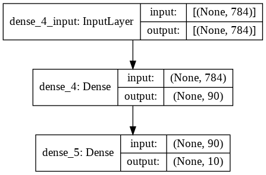

```python
keras.utils.plot_model(model, "mnist_model_1hnode.png", show_shapes=True) # plot a graph of the model
```

```python
model.summary() # prints a summary representation of the odel
```

```
Model: "sequential_3"
_________________________________________________________________
Layer (type)                 Output Shape              Param #
=================================================================
dense_4 (Dense)              (None, 90)                70650
_________________________________________________________________
dense_5 (Dense)              (None, 10)                910
=================================================================
Total params: 71,560
Trainable params: 71,560
Non-trainable params: 0
_________________________________________________________________
```

### Compiling the model

To make our network ready for training, we need to pick three more things, as part of "compilation" step:

A loss function: the is how the network will be able to measure how good a job it is doing on its training data, and thus how it will be able to steer itself in the right direction. An optimizer: this is the mechanism through which the network will update itself based on the data it sees and its loss function. Metrics to monitor during training and testing. Here we will only care about accuracy (the fraction of the images that were correctly classified).

```python
# For use with non-categorical labels
model.compile(optimizer='rmsprop',
                loss='sparse_categorical_crossentropy',
                metrics=['accuracy'])
```

## Training the model

We are now ready to train our network, which in Keras is done via a call to the fit method of the network: we "fit" the model to its training data. We train the model for 30 epochs with batch size 32 (the default).

```python
history = model.fit(train_images, train_labels, epochs=30,
                    validation_data=(val_images, val_labels))
```

```python
hist_dict = history.history
hist_dict.keys()
```

```
dict_keys(['loss', 'accuracy', 'val_loss', 'val_accuracy'])
```

```python
print(f'''acc: {hist_dict['accuracy'][-1]:.4}, val acc: {hist_dict['val_accuracy'][-1]:.4},
loss: {hist_dict['loss'][-1]:.4}, val loss: {hist_dict['val_loss'][-1]:.4}''')
```

```
acc: 0.9981, val acc: 0.9744,
loss: 0.00845, val loss: 0.1637
```

## Testing the model

Evaluate the model on the test dataset.

```python
test_loss, test_acc = model.evaluate(test_images, test_labels)
```

```python
print(f'test acc: {test_acc}, test loss: {test_loss}')
```

```
test acc: 0.9742000102996826, test loss: 0.16729983687400818
```

## Building, training and testing the model on the new data

We modify the model to take input with dimension (154,)

```python
#from tensorflow.keras import models
#from tensorflow.keras import layers

model = models.Sequential()
model.add(layers.Dense(90, activation='relu', input_shape=(154,)))
model.add(layers.Dense(10, activation='softmax'))

# For use with non-categorical labels
model.compile(optimizer='rmsprop',
                loss='sparse_categorical_crossentropy',
                metrics=['accuracy'])
history = model.fit(train_images_red, train_labels, epochs=30,
                    validation_data=(val_images_red, val_labels))
```

```python
history_dict = history.history
history_dict.keys()
```

```
dict_keys(['loss', 'accuracy', 'val_loss', 'val_accuracy'])
```

```python
print(f'''acc: {hist_dict['accuracy'][-1]:.4}, val acc: {hist_dict['val_accuracy'][-1]:.4},
loss: {hist_dict['loss'][-1]:.4}, val loss: {hist_dict['val_loss'][-1]:.4}''')
```

```
acc: 0.9981, val acc: 0.9744,
loss: 0.00845, val loss: 0.1637
```

## Testing the model

Evaluate the model on the test dataset.

```python
test_loss, test_acc = model.evaluate(test_images_red, test_labels)
```

```python
print(f'test acc: {test_acc}, test loss: {test_loss}')
```

```
test acc: 0.9749000072479248, test loss: 0.1776966005563736
```

# Comparison of the two models

Reducing the dimensions from 784 to 154 had no negative impact on the performance of our 'best' model.

## Plotting the performance

```python
history_dict = history.history
history_dict.keys()
```

```
dict_keys(['loss', 'accuracy', 'val_loss', 'val_accuracy'])
```

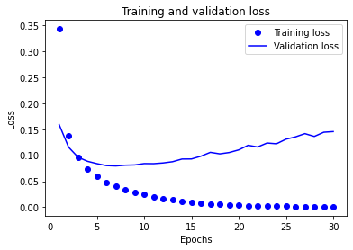

```python
import matplotlib.pyplot as plt

acc = history.history['accuracy']
val_acc = history.history['val_accuracy']
loss = history.history['loss']
val_loss = history.history['val_loss']

epochs = range(1, len(acc) + 1)

# "bo" is for "blue dot"
plt.plot(epochs, loss, 'bo', label='Training loss')
# b is for "solid blue line"
plt.plot(epochs, val_loss, 'b', label='Validation loss')
plt.title('Training and validation loss')

plt.xlabel('Epochs')
plt.ylabel('Loss')
plt.legend()

plt.show()
```

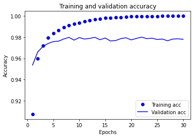

```python
plt.clf()   # clear figure
acc_values = history_dict['accuracy']
# val_acc_values = history_dict['val_acc']

plt.plot(epochs, acc, 'bo', label='Training acc')
plt.plot(epochs, val_acc, 'b', label='Validation acc')
plt.title('Training and validation accuracy')

plt.xlabel('Epochs')
plt.ylabel('Accuracy')
plt.legend()

plt.show()
```